# Visualizing Big Datasets: Tools, Pitfalls, Experimental Example

### Importance of Data Visualization - NYC Taxi pick-upp data

[figure not shown]

# Plotting very large datasets meaningfully

[figure not shown]

- to provide clear understanding
- to aid decision making

### We can always look at statistics, but with big dataset visualization can get a good feeling!

[figure not shown]

## Visualization Bias: Same Data, Different Visualization

[figure not shown]

# Problems?

# Presentation Outine:

- Tools introduction
- Ratcave VR Acuity introduction
- Pitfalls of Large Datasets Vizualization with Real Data Example

# Tools

[figure not shown]

Python Library providing high-performance data manipulation and analysis tool using powerful data structures

- DataFrame objects, with customazed and default indexing
- Loading data into in-memory data object
- Data alignment and handling of missing data.
- Reshaping, operations on columns
- Group by data, mergeging and joining of data
- Time Series functionality.

```python
import pandas as pd
```

### Creating structured dataset

```python
data = pd.DataFrame(np.random.randn(500,3), columns=['X','Y','Z'])
data.X
```

```
0     -0.051869
1     -1.424738
2     -0.993653
3      0.987935
4      1.137393
5      0.548313
6      0.008722
7     -0.855077
8      1.082083
9     -0.133629
10    -0.543566
11     0.659367
12     0.638991
13     0.380112
14     0.464291
```

[output cut: 47 more lines]

### Operations on columns

```python
data.X = data.X * 20
data.head()
```

|  | X | Y | Z |
| --- | --- | --- | --- |
| 0 | -1.037381 | 2.057066 | 0.826568 |
| 1 | -28.494756 | 2.308699 | 0.430217 |
| 2 | -19.873051 | 0.444620 | 0.518858 |
| 3 | 19.758695 | 2.075821 | -0.385681 |
| 4 | 22.747857 | 0.474595 | 1.043406 |

### Adding new column: label

```python
x = np.array([[1,2,3,4,5]])
data['label'] = np.repeat(x, 100)

data.head()
```

|  | X | Y | Z | label |
| --- | --- | --- | --- | --- |
| 0 | -1.037381 | 2.057066 | 0.826568 | 1 |
| 1 | -28.494756 | 2.308699 | 0.430217 | 1 |
| 2 | -19.873051 | 0.444620 | 0.518858 | 1 |
| 3 | 19.758695 | 2.075821 | -0.385681 | 1 |
| 4 | 22.747857 | 0.474595 | 1.043406 | 1 |

### Describing statistics of the data

```python
data.describe()
```

|  | X | Y | Z | label |
| --- | --- | --- | --- | --- |
| count | 500.000000 | 500.000000 | 500.000000 | 500.00000 |
| mean | 0.473253 | -0.046197 | -0.005736 | 3.00000 |
| std | 20.051941 | 1.024683 | 1.015984 | 1.41563 |
| min | -57.251210 | -2.688469 | -3.397722 | 1.00000 |
| 25% | -13.237542 | -0.705893 | -0.692804 | 2.00000 |
| 50% | -0.312539 | -0.067007 | -0.008974 | 3.00000 |
| 75% | 14.232331 | 0.633444 | 0.606323 | 4.00000 |
| max | 61.998916 | 3.265027 | 3.047926 | 5.00000 |

[figure not shown]

Python visualization library based on matplotlib. It provides a high-level interface for drawing attractive statistical graphics.

- Visualizing univariate and bivariate distributions and comparing them between subsets of data
- Tools that fit and visualize linear regression models
- Functions that visualize matrices of data
- Several built-in themes for styling matplotlib graphics
- Tools for choosing color palettes - to reveal patterns in your data

```python
import seaborn as sns
```

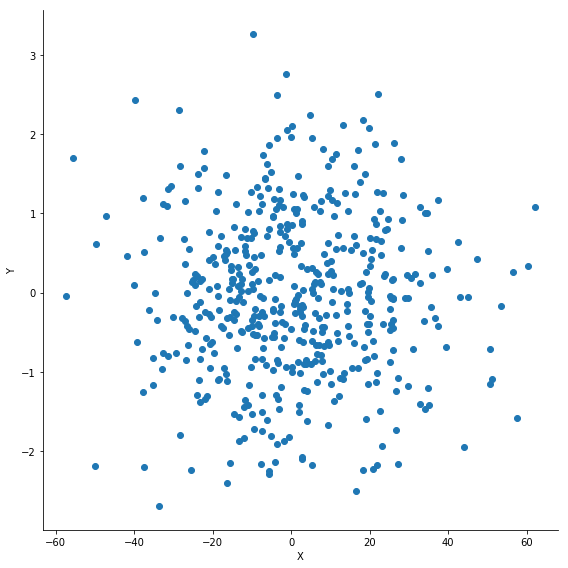

```python
g = sns.FacetGrid(data=data, size=8);
g.map(plt.scatter, 'X', 'Y');
```

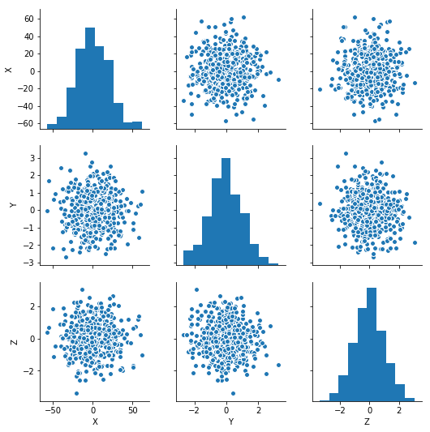

```python
sns.pairplot(data=data, vars=['X', 'Y', 'Z'] );
```

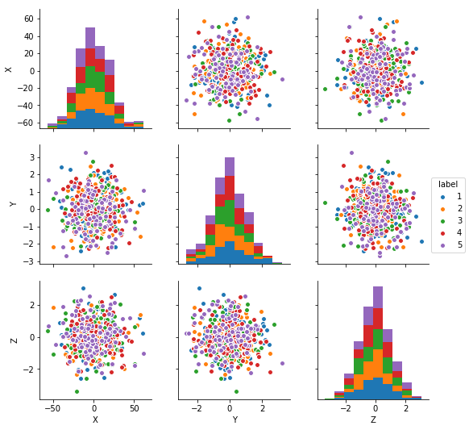

```python
## Adding hue
sns.pairplot(data=data, vars=['X', 'Y', 'Z'], hue='label');
```

[figure not shown]

# Datashader

Datashader is a Python library for analyzing and visualizing large datasets. Designed to **"rasterize"** or **"aggregate"** datasets into regular grids that can be viewed as images. Datashader breaks the creation of images of data into 3 main steps:

1. Projection - Each record is projected into zero or more bins of a grid shape.
2. Aggregation - Reductions are computed for each bin, compressing the potentially large dataset into a much smaller aggregate array.
3. Transformation - These aggregates are then further processed, eventually creating an image.

[figure not shown]

https://python-graph-gallery.com/

# Experiment

## Ratcave

[figure not shown]

## Ratcave Virtual Reality: Acuity Measurment Project

[figure not shown]

# Dataset explenation: position and orientation

[figure not shown]

## What are we looking for: Stimuli Related Behavior

[figure not shown]

# Pitfalls of Large Datasets Vizualization

## Loading The Dataset

Another feature of pandas in practice.

```python
path = 'data/'
dfrat = pd.read_hdf(path+'relationalDatabase.h5', 'Rat_Behavior').set_index('index')
dfrat.describe()
```

|  | Frame | Time | X_Pos | Y_Pos | Z_Pos | X_Ori | Y_Ori | Z_Ori | session_id |
| --- | --- | --- | --- | --- | --- | --- | --- | --- | --- |
| count | 1.280662e+06 | 1.280662e+06 | 1.280662e+06 | 1.280662e+06 | 1.280662e+06 | 1.280662e+06 | 1.280662e+06 | 1.280662e+06 | 1.280662e+06 |
| mean | 9.073073e+04 | 3.780447e+02 | 4.171135e-03 | 1.126962e-01 | -1.757355e-02 | -1.764554e-02 | -1.764985e-01 | -5.330155e-02 | 3.427937e+00 |
| std | 5.483929e+04 | 2.284971e+02 | 5.472566e-02 | 5.773475e-02 | 5.453772e-02 | 5.957492e-01 | 4.486547e-01 | 6.399129e-01 | 2.165823e+00 |
| min | 0.000000e+00 | 0.000000e+00 | -9.420275e-02 | 4.327843e-02 | -9.999978e-02 | -9.999981e-01 | -9.999986e-01 | -9.999998e-01 | 0.000000e+00 |
| 25% | 4.533000e+04 | 1.888750e+02 | -4.663273e-02 | 7.851390e-02 | -6.850875e-02 | -5.427750e-01 | -5.608227e-01 | -6.578161e-01 | 2.000000e+00 |
| 50% | 8.876300e+04 | 3.698459e+02 | 8.407816e-04 | 9.655091e-02 | -2.171306e-02 | -2.256700e-02 | -1.453605e-01 | -7.001106e-02 | 3.000000e+00 |
| 75% | 1.312200e+05 | 5.467500e+02 | 5.410460e-02 | 1.157454e-01 | 3.207740e-02 | 5.280534e-01 | 1.285384e-01 | 5.372806e-01 | 5.000000e+00 |
| max | 2.452310e+05 | 1.021796e+03 | 1.274465e-01 | 2.999993e-01 | 8.559266e-02 | 9.999951e-01 | 9.761727e-01 | 9.999952e-01 | 7.000000e+00 |

```python
dfrat.describe()
```

## Taking the subsection - for the sake of plotting speed

```python
mask = dfrat.session_id == 0
rat = dfrat[mask]
rat.head()
rat.tail()
```

| index | Frame | Time | X_Pos | Y_Pos | Z_Pos | X_Ori | Y_Ori | Z_Ori | session_id |
| --- | --- | --- | --- | --- | --- | --- | --- | --- | --- |
| 159380 | 159380 | 664.083376 | -0.017551 | 0.186103 | 0.046540 | 0.241129 | -0.198757 | 0.949922 | 0 |
| 159381 | 159381 | 664.087542 | -0.017141 | 0.184863 | 0.046914 | 0.254070 | -0.211804 | 0.943710 | 0 |
| 159382 | 159382 | 664.091709 | -0.016698 | 0.183512 | 0.047313 | 0.265572 | -0.226651 | 0.937070 | 0 |
| 159383 | 159383 | 664.095876 | -0.016304 | 0.182186 | 0.047606 | 0.275242 | -0.246051 | 0.929355 | 0 |
| 159384 | 159384 | 664.100042 | -0.015926 | 0.180857 | 0.048112 | 0.286543 | -0.259080 | 0.922372 | 0 |

```python
mask2 = (dfrat.session_id == 1) | (dfrat.session_id == 2)
rat2 = dfrat[mask2]

rat2.tail(2)
```

| index | Frame | Time | X_Pos | Y_Pos | Z_Pos | X_Ori | Y_Ori | Z_Ori | session_id |
| --- | --- | --- | --- | --- | --- | --- | --- | --- | --- |
| 188299 | 188299 | 784.579217 | 0.024437 | 0.107252 | 0.035597 | 0.295940 | 0.152368 | 0.942976 | 2 |
| 188300 | 188300 | 784.583383 | 0.024471 | 0.107232 | 0.035564 | 0.296564 | 0.147740 | 0.943516 | 2 |

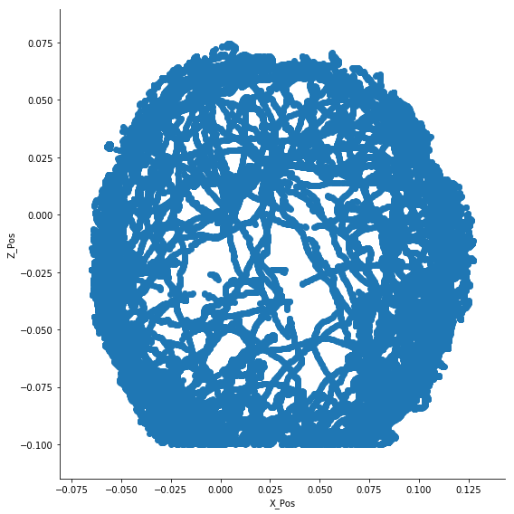

```python
g = sns.FacetGrid(data=rat, size=8)
g.map(plt.scatter,'X_Pos','Z_Pos');
```

## 1. Overplotting

- 2 x 2D subsets - two separate experiments, plotted togheter

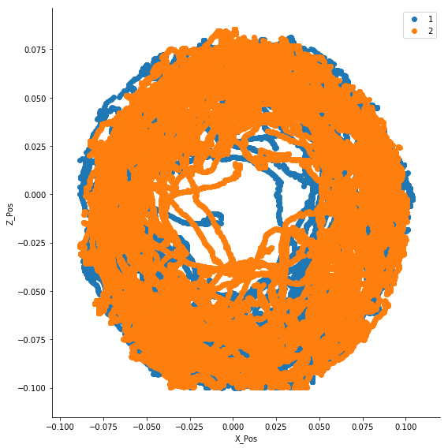

```python
g = sns.FacetGrid(data=rat2, size=8, hue='session_id')
g.map(plt.scatter,'X_Pos','Z_Pos');
plt.legend();
```

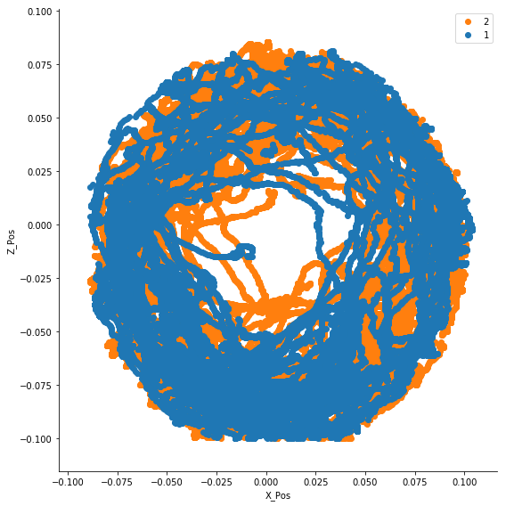

```python
g = sns.FacetGrid(data=rat2, size=8, hue='session_id', hue_order=[2,1], palette=["C1", "C0"] )
g.map(plt.scatter,'X_Pos','Z_Pos');
plt.legend();
```

## Apperance depeneds on which one is plotted first!

### Occlusion of Data - points plotted on top of one another

# Alpha Parameter

Reduce the problem of overplotting by using the transparency parameter.

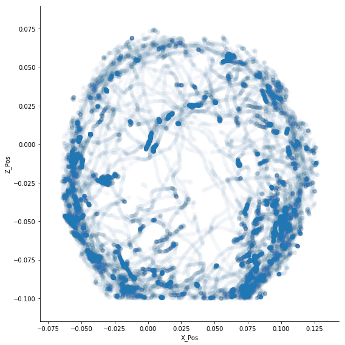

```python
g = sns.FacetGrid(data=rat, size=8)
g.map(plt.scatter,'X_Pos','Z_Pos', alpha=0.01);
```

# 2. Oversaturation

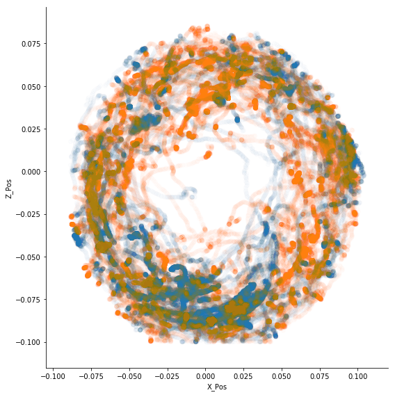

```python
g = sns.FacetGrid(data=rat2, size=8, hue='session_id' )
g.map(plt.scatter,'X_Pos','Z_Pos', alpha=0.01);
```

## What else can we do?

## Add another Hyperparameter: point size

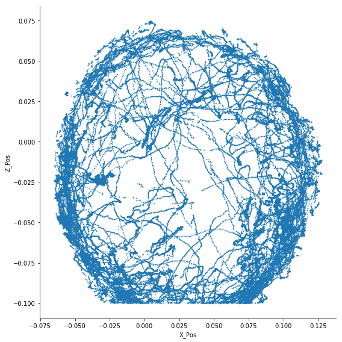

```python
g = sns.FacetGrid(data=rat, size=8)
g.map(plt.scatter,'X_Pos','Z_Pos', s=0.5);
```

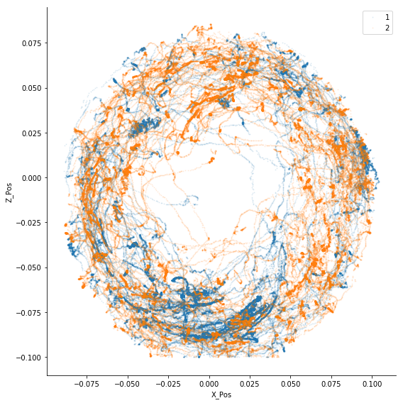

```python
g = sns.FacetGrid(data=rat2, size=8, hue='session_id')
g.map(plt.scatter,'X_Pos','Z_Pos', s=0.9, alpha=0.1);
plt.legend();
```

## We can take part of the dataset

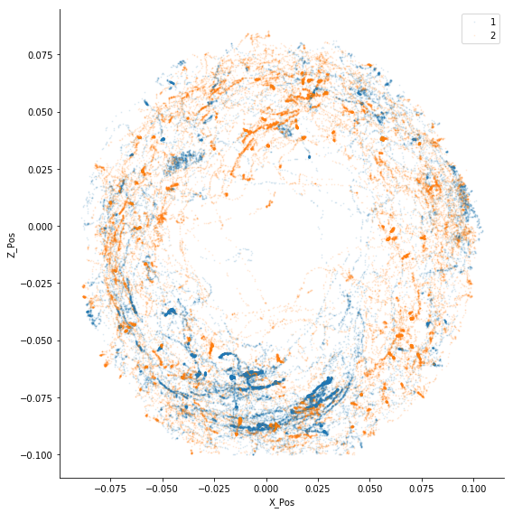

```python
g = sns.FacetGrid(data=rat2.sample(100000), size=8, hue='session_id')
g.map(plt.scatter,'X_Pos','Z_Pos', s=0.9, alpha=0.1);
plt.legend();
```

## 3. Undersampling

## We got better results, but the choice of the two hyperparameters strongly depeneds on the Dataset!

# Heatmaps

```python
from matplotlib import colors

def make_heatmap(x, y, bins=20, cmap='viridis', **kwargs):
    hist = np.histogram2d(x, y, bins=bins)[0]
    return plt.imshow(hist, cmap=cmap, origin='lower')
```

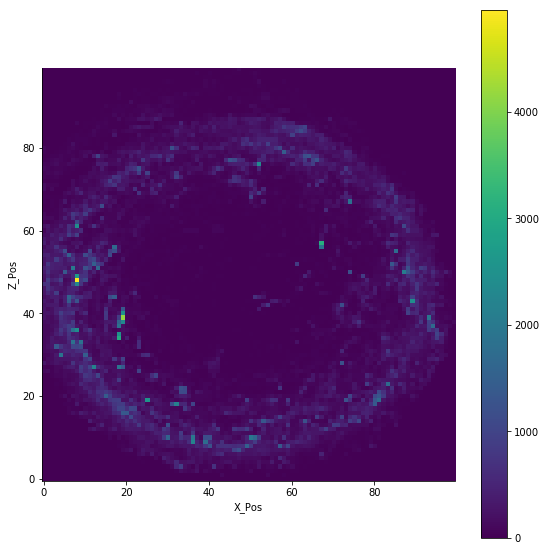

```python
g = sns.FacetGrid(data=dfrat, size=8)
g.map(make_heatmap,'X_Pos','Z_Pos', bins=100);
plt.colorbar()
```

# 4. Undersaturation

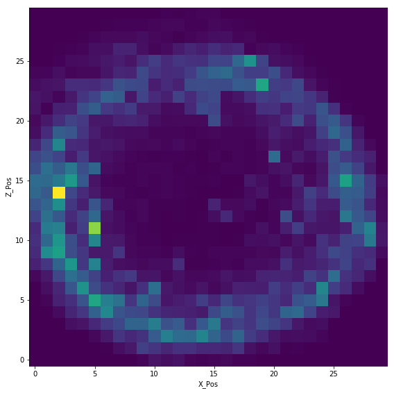

```python
g = sns.FacetGrid(data=dfrat, size=8)
g.map(make_heatmap,'X_Pos','Z_Pos', bins=30);
```

# Color Pallete

https://seaborn.pydata.org/tutorial/color_palettes.html

[figure not shown]

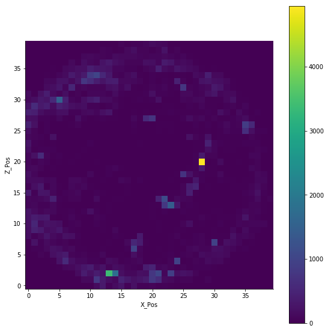

```python
# viridis_r, rainbow, icefire_r
g = sns.FacetGrid(data=rat, size=8);
g.map(make_heatmap,'X_Pos','Z_Pos', cmap='viridis', bins=40);
plt.colorbar()
```

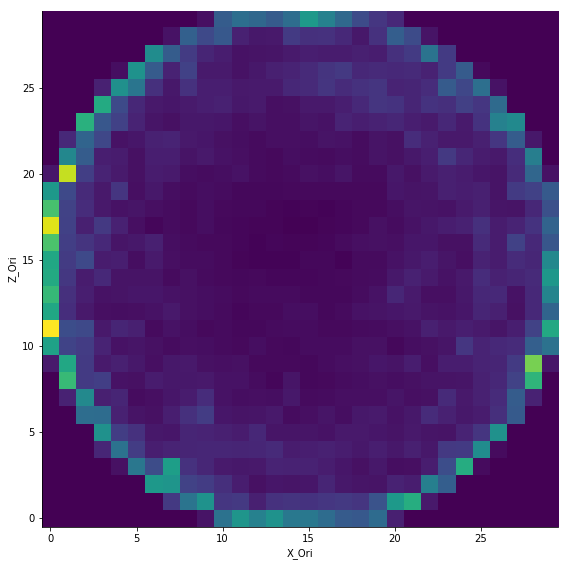

```python
g = sns.FacetGrid(data=dfrat, size=8)
g.map(make_heatmap,'X_Ori','Z_Ori', bins=30);
```

# Taking it a step further!

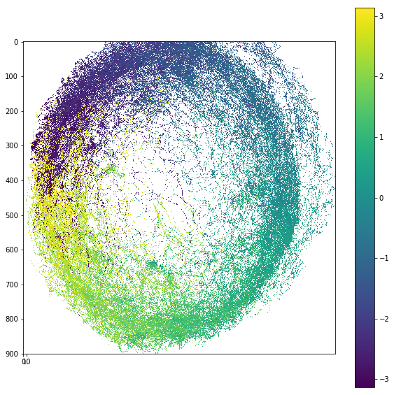

```python
cvs = ds.Canvas(plot_height=900, plot_width=900)
agg_z =cvs.points(source=dfrat, x='X_Pos', y='Z_Pos', agg=ds.mean('Z_Ori'))
agg_x =cvs.points(source=dfrat, x='X_Pos', y='Z_Pos', agg=ds.mean('X_Ori'))
agg_xn = agg_x / np.sqrt(agg_x ** 2 + agg_z ** 2)
agg_zn = agg_z / np.sqrt(agg_x ** 2 + agg_z ** 2)
theta = np.arctan2(agg_zn, agg_xn)
cm.hsv.set_bad('black')
plt.figure(figsize=(10, 10))
plt.imshow(theta)
plt.xticks([0, 10])
plt.colorbar();
```

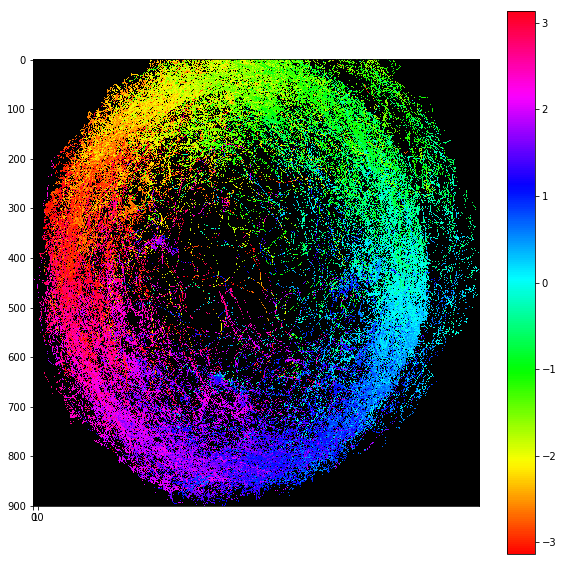

```python
cvs = ds.Canvas(plot_height=900, plot_width=900)
agg_z =cvs.points(source=dfrat, x='X_Pos', y='Z_Pos', agg=ds.mean('Z_Ori'))
agg_x =cvs.points(source=dfrat, x='X_Pos', y='Z_Pos', agg=ds.mean('X_Ori'))
agg_xn = agg_x / np.sqrt(agg_x ** 2 + agg_z ** 2)
agg_zn = agg_z / np.sqrt(agg_x ** 2 + agg_z ** 2)
theta = np.arctan2(agg_zn, agg_xn)
cm.hsv.set_bad('black')
plt.figure(figsize=(10, 10))
plt.imshow(theta)
plt.imshow(theta, cmap=cm.hsv)
plt.xticks([0, 10])
plt.colorbar();
```

[figure not shown]

# Summary:

## What should we keep in mind, when working with big datasets:

### Scatter plots - 3 hyperparameters:

- overplotting - avoid obsccuring the data
- saturation - 10, 100, 6000 points under 10 points limit
- undersampling - taking a subset might not be an answer

### Heatmaps - 1 hyperparameter:

# Extra Examples

## Ratcave Arena

[figure not shown]

## Color Rearing

[figure not shown]

# Thank you for your attention!

[figure not shown]